# title: **“S5 Contaminantes del aire en India”**

## Año 2017

```r
xbarra_PM10_17 = mean(DF17$PM10)
s_PM10_17 = sd(DF17$PM10)
est_PM10_17 = estadistico(xbarra_PM10_17,s_PM10_17,n_17,20)

valor_critico_17
```

```
## [1] 1.644954
```

```r
est_PM10_17
```

```
## [1] 142.5462
```

```r
range(DF17$PM10)
```

```
## [1]   3.00 988.65
```

```r
int_conf(xbarra_PM10_17,s_PM10_17,valor_critico_17,n_17)
```

```
## [1] 142.89 145.76
```

$$[142.89,145.76]$$

## Año 2018

```r
xbarra_PM10_18 = mean(DF18$PM10)
s_PM10_18 = sd(DF18$PM10)
est_PM10_18 = estadistico(xbarra_PM10_18,s_PM10_18,n_18,20)

valor_critico_18
```

```
## [1] 1.644908
```

```r
est_PM10_18
```

```
## [1] 199.3004
```

```r
range(DF18$PM10)
```

```
## [1]   3.67 999.99
```

```r
int_conf(xbarra_PM10_18,s_PM10_18,valor_critico_18,n_18)
```

```
## [1] 150.31 152.48
```

$$[150.31,152.48]$$

## Año 2019

```r
xbarra_PM10_19 = mean(DF19$PM10)
s_PM10_19 = sd(DF19$PM10)
est_PM10_19 = estadistico(xbarra_PM10_19,s_PM10_19,n_19,20)

valor_critico_19
```

```
## [1] 1.644893
```

```r
est_PM10_19
```

```
## [1] 205.2974
```

```r
range(DF19$PM10)
```

```
## [1]    2 1000
```

```r
int_conf(xbarra_PM10_19,s_PM10_19,valor_critico_19,n_19)
```

```
## [1] 123.39 125.06
```

$$[123.39,125.06]$$

Conclusión: Sí rechazamos H0, porque el estadístico de prueba está en la zona de rechazo. Además, se observa que para un nivel de confianza de 95%, para el año 2017 el estadístico de prueba es muy cercano al intervalo de confianza para la cantidad promedio de PM10. En todos los años se cumple que la cantidad de promedio de PM10 sobrepasa el límite permisible de 20 ug/m3, por lo que los habitantes pueden percibir una exposición crónica a las partículas que agrava el riesgo de desarrollar cardiopatías y neumopatías, así como cáncer de pulmón

Extraído de: https://bit.ly/3y1jVUf

Hipótesis: La cantidad promedio de NO2 anual es mayor a 40 ug/m3.

Pregunta: ¿La cantidad promedio de NO2 anual sobrepasa el límite permisible de 40 ug/m3?

## Prueba de hipótesis sobre NO2 entre los años 2017-2019

$$H_0:µ<=40$$
$$H_1:µ>40$$

[figure not shown]

## Año 2017

```r
xbarra_NO2_17 = mean(DF17$NO2)
s_NO2_17 = sd(DF17$NO2)
est_NO2_17 = estadistico(xbarra_NO2_17,s_NO2_17,n_17,40)

valor_critico_17
```

```
## [1] 1.644954
```

```r
est_NO2_17
```

```
## [1] -19.81442
```

```r
range(DF17$NO2)
```

```
## [1]   0.13 244.65
```

```r
int_conf(xbarra_NO2_17,s_NO2_17,valor_critico_17,n_17)
```

```
## [1] 35.96 36.58
```

$$[35.96,36.58]$$

## Año 2018

```r
xbarra_NO2_18 = mean(DF18$NO2)
s_NO2_18 = sd(DF18$NO2)
est_NO2_18 = estadistico(xbarra_NO2_18,s_NO2_18,n_18,40)

valor_critico_18
```

```
## [1] 1.644908
```

```r
est_NO2_18
```

```
## [1] -0.9089018
```

```r
range(DF18$NO2)
```

```
## [1]   0.1 178.4
```

```r
int_conf(xbarra_NO2_18,s_NO2_18,valor_critico_18,n_18)
```

```
## [1] 39.65 40.10
```

$$[39.65,40.10]$$

## Año 2019

```r
xbarra_NO2_19 = mean(DF19$NO2)
s_NO2_19 = sd(DF19$NO2)
est_NO2_19 = estadistico(xbarra_NO2_19,s_NO2_19,n_19,40)

valor_critico_19
```

```
## [1] 1.644893
```

```r
est_NO2_19
```

```
## [1] -78.59608
```

```r
range(DF19$NO2)
```

```
## [1]   0.10 264.11
```

```r
int_conf(xbarra_NO2_19,s_NO2_19,valor_critico_19,n_19)
```

```
## [1] 30.76 31.14
```

$$[30.76,31.14]$$

Conclusión: No rechazamos H0, porque el estadístico de prueba no está en la zona de rechazo. En los años 2017 y 2019 se cumple que la cantidad promedio poblacional de NO2 es menor al límite permisible de 40 ug/m3 establecido por la OMS. Por otro lado, en el año 2018, puede que la media poblacional sobrepase el límite permisible de NO2. Por ahora, los habitantes no están expuestos a cantidades dañinas para su salud, por lo que no desarrollarán posibles quemaduras, espasmos y/o dilataciones de los tejidos en la garganta y las vías respiratorias superiores, evitando así reducir la oxigenación de sus tejidos del cuerpo y producir acumulación del líquido en los pulmones y la muerte.

Extraído de: https://bit.ly/3eQ4BCe

### Relaciones

Respecto a las relaciones que encontramos anteriormente entre la variables, buscamos su regresión lineal.

#### PM10 Y AQI

La correlación entre el PM10 y el AQI es:

```
## [1] 0.8105313
```

Con eso podemos determinar que existe una buena correlación entre variables; asimismo, con ello buscamos un modelo que explique la correlación entre las variables. En ese sentido determinamos lo siguiente:

```
##
## Call:
## lm(formula = AQI ~ PM10, data = DFCH1)
##
## Residuals:
##     Min      1Q  Median      3Q     Max
## -725.12  -30.92  -12.28   18.61  520.14
##
## Coefficients:
##             Estimate Std. Error t value Pr(>|t|)
## (Intercept) 43.90776    0.25804   170.2   <2e-16 ***
## PM10         0.79122    0.00159   497.6   <2e-16 ***
## ---
## Signif. codes:  0 '***' 0.001 '**' 0.01 '*' 0.05 '.' 0.1 ' ' 1
##
## Residual standard error: 56.82 on 129275 degrees of freedom
## Multiple R-squared:  0.657,  Adjusted R-squared:  0.657
## F-statistic: 2.476e+05 on 1 and 129275 DF,  p-value: < 2.2e-16
```

```
## (Intercept)        PM10
##  43.9077628   0.7912247
```

Variable - PM10

$$H_0:\beta_1=0$$
$$H_1:\beta_1≠0$$

Análisis: Respecto a los coeficientes, el intercepto tiene un p value de 2e-16 y la variable PM10 tiene un p value de 2e-16, lo cual es menor al nivel de significancia (0.05) y por tanto rechazamos la hipótesis nula, lo que muestra que tanto el intercepto como la variable PM10 sí aportan al modelo propuesto.

Modelo:

Respecto al modelo, se tiene un p value de 2.2e-16, lo cual es menor al nivel de significancia (0.05), lo que muestra que el modelo sí es significativo.

Función:
$$Y = 0.7912247x +
43.9077628$$
Donde: x : Valor de PM 10 y: Valor de AQI

$$R^2=0.657$$

0.657 de la variación del AQI está representado por la variación del valor del PM10.

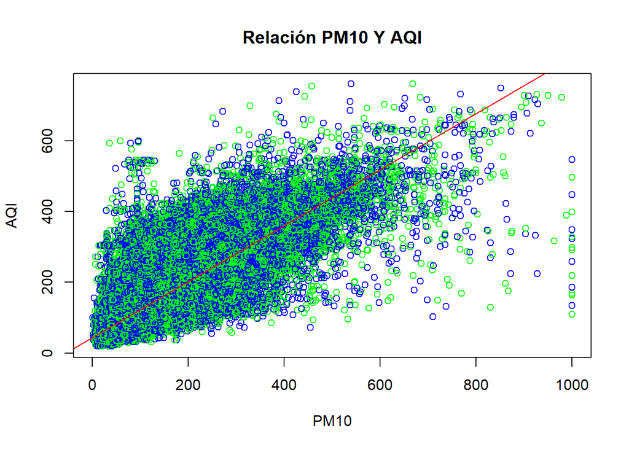

```r
plot(DFCH1$PM10,DFCH1$AQI,main="Relación PM10 Y AQI",xlab="PM10",ylab="AQI",col=c("green","blue")) #Grafico
abline(modelo1,col="red")
```

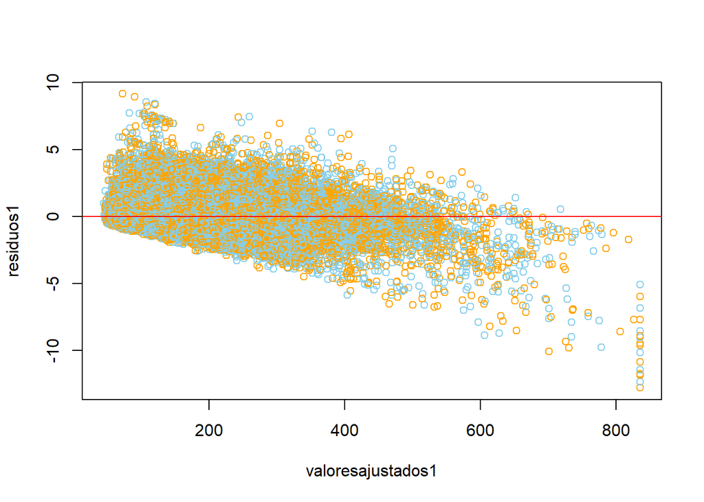

```r
#residuos
residuos1=rstandard(modelo1)
valoresajustados1=fitted(modelo1)
plot(valoresajustados1,residuos1,col=c("orange","skyblue"))
abline(h=0,col="red")
```

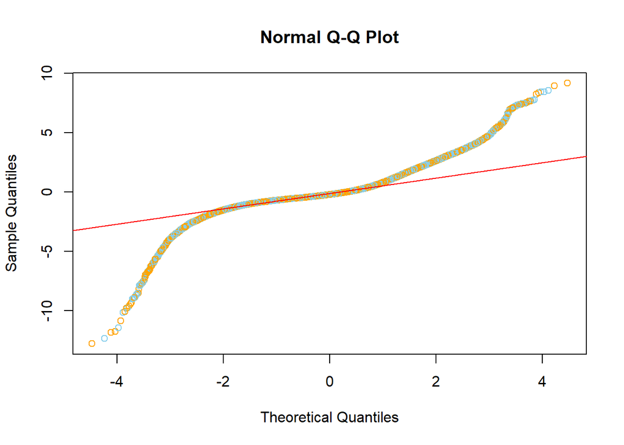

```r
#normalidad
qqnorm(residuos1,col=c("orange","skyblue"))
qqline(residuos1,col="red")
```

#### PM2.5 Y AQI

La correlación entre el PM2.5 y el AQI es:

```
## [1] 0.8136211
```

```
## [1] 0.8136211
```

```
##
##  Pearson's product-moment correlation
##
## data:  DFCH1$PM2.5 and DFCH1$AQI
## t = 503.16, df = 129275, p-value < 2.2e-16
## alternative hypothesis: true correlation is not equal to 0
## 95 percent confidence interval:
##  0.8117703 0.8154556
## sample estimates:
##       cor
## 0.8136211
```

```
##
## Call:
## lm(formula = DFCH1$AQI ~ DFCH1$PM2.5)
##
## Residuals:
##      Min       1Q   Median       3Q      Max
## -1036.28   -33.08   -12.58    19.45   509.23
##
## Coefficients:
##              Estimate Std. Error t value Pr(>|t|)
## (Intercept) 64.230010   0.225023   285.4   <2e-16 ***
## DFCH1$PM2.5  1.269942   0.002524   503.2   <2e-16 ***
## ---
## Signif. codes:  0 '***' 0.001 '**' 0.01 '*' 0.05 '.' 0.1 ' ' 1
##
## Residual standard error: 56.4 on 129275 degrees of freedom
## Multiple R-squared:  0.662,  Adjusted R-squared:  0.662
## F-statistic: 2.532e+05 on 1 and 129275 DF,  p-value: < 2.2e-16
```

```
## (Intercept) DFCH1$PM2.5
##   64.230010    1.269942
```

Variable - PM2.5

$$H_0:\beta_1=0$$
$$H_1:\beta_1≠0$$

Modelo:

H0: El modelo no es significativo.

Respecto al modelo, se tiene un p value de 2.2e-16, lo cual es menor al nivel de significancia (0.05) y por tanto rechazamos la hipótesis nula, lo que muestra que el modelo sí es significativo.

Función:
$$Y = 1.269942x
+64.230010$$
Donde: x : Valor de PM2.5 y: Valor de AQI

$$R^2=0.662$$

0.662 de la variación del AQI está representado por la variación del valor del PM2.5.

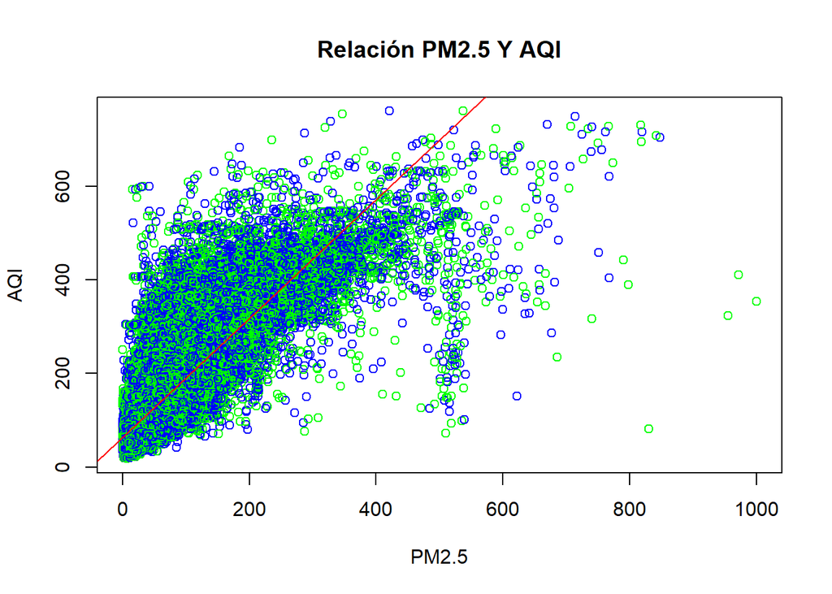

```r
plot(DFCH1$PM2.5,DFCH1$AQI,main="Relación PM2.5 Y AQI",xlab="PM2.5",ylab="AQI",col=c("green","blue"))
abline(modelo4,col="red")
```

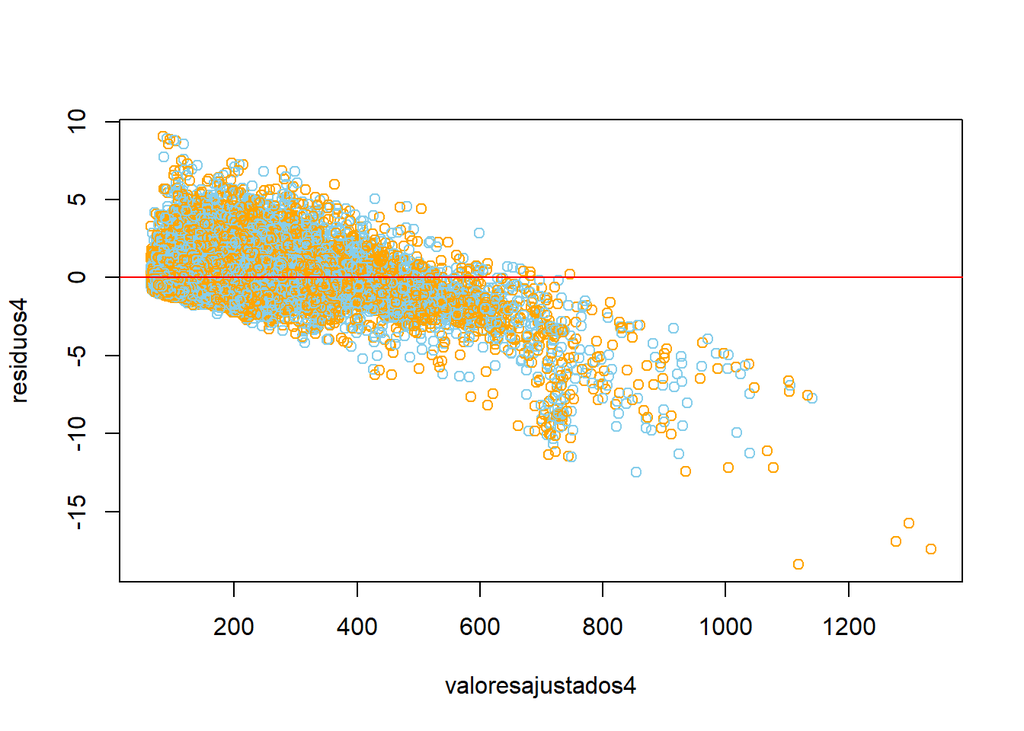

```r
#residuos
residuos4=rstandard(modelo4)
valoresajustados4=fitted(modelo4)
plot(valoresajustados4,residuos4,col=c("orange","skyblue"))
abline(h=0,col="red")
```

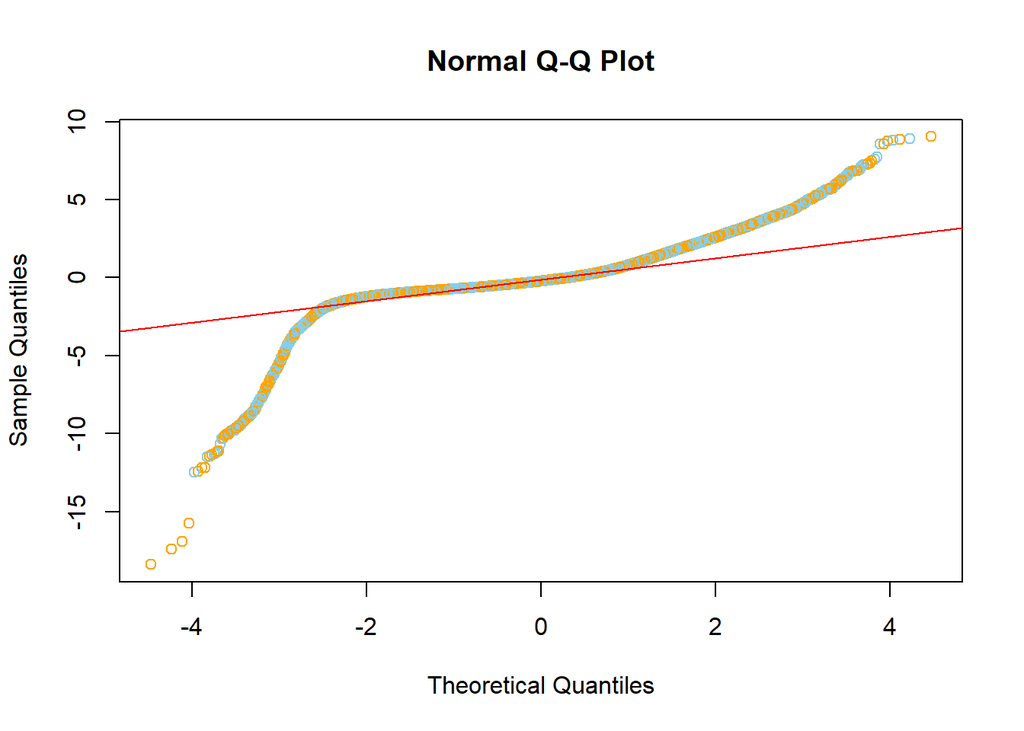

```r
#normalidad
qqnorm(residuos4,col=c("orange","skyblue"))
qqline(residuos4,col="red")
```

#### PM10 Y PM2.5

La correlación entre el PM10 y el PM2.5 es:

```
## [1] 0.8626023
```

```
## [1] 0.8626023
```

```
##
##  Pearson's product-moment correlation
##
## data:  DFCH1$PM10 and DFCH1$PM2.5
## t = 613.08, df = 129275, p-value < 2.2e-16
## alternative hypothesis: true correlation is not equal to 0
## 95 percent confidence interval:
##  0.8612007 0.8639908
## sample estimates:
##       cor
## 0.8626023
```

```
##
## Call:
## lm(formula = DFCH1$PM2.5 ~ DFCH1$PM10)
##
## Residuals:
##     Min      1Q  Median      3Q     Max
## -523.23  -10.60   -0.01    8.72  918.20
##
## Coefficients:
##             Estimate Std. Error t value Pr(>|t|)
## (Intercept) -5.28402    0.14279  -37.01   <2e-16 ***
## DFCH1$PM10   0.53948    0.00088  613.08   <2e-16 ***
## ---
## Signif. codes:  0 '***' 0.001 '**' 0.01 '*' 0.05 '.' 0.1 ' ' 1
##
## Residual standard error: 31.44 on 129275 degrees of freedom
## Multiple R-squared:  0.7441, Adjusted R-squared:  0.7441
## F-statistic: 3.759e+05 on 1 and 129275 DF,  p-value: < 2.2e-16
```

```
## (Intercept)  DFCH1$PM10
##  -5.2840161   0.5394843
```

Variable - PM10

$$H_0:\beta_1=0$$
$$H_1:\beta_1≠0$$

Análisis: Respecto a los coeficientes, el intercepto tiene un p value de 2e-16 y la variable PM10 tiene un p value de 2e-16, lo cual es menor al nivel de significancia (0.05) y por tanto rechazamos la hipótesis nula, lo que muestra que tanto el intercepto como la variable PM10 sí aportan al modelo propuesto.

Modelo:

Respecto al modelo, se tiene un p value de 2.2e-16, lo cual es menor al nivel de significancia (0.05) y por tanto rechazamos la hipótesis nula, lo que muestra que el modelo sí es significativo.

Función:
$$Y = 0.5394843x
-5.2840161$$
Donde: x : Valor de PM10 y: Valor de PM2.5

$$R^2=0.7441$$

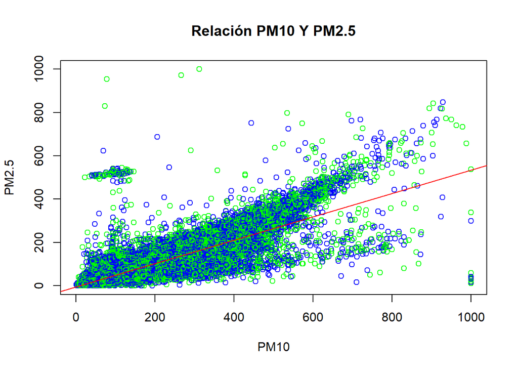

```r
plot(DFCH1$PM10,DFCH1$PM2.5,main="Relación PM10 Y PM2.5",xlab="PM10",ylab="PM2.5",col=c("green","blue"))
abline(modelo2,col="red")
```

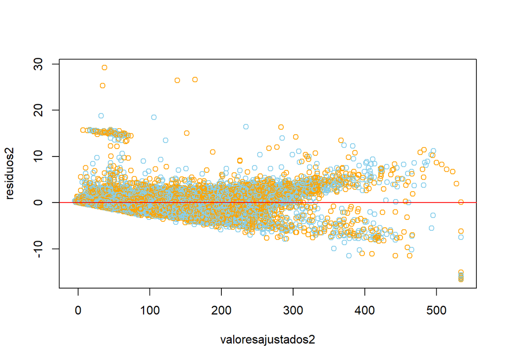

```r
#residuos
residuos2=rstandard(modelo2)
valoresajustados2=fitted(modelo2)
plot(valoresajustados2,residuos2,col=c("orange","skyblue"))
abline(h=0,col="red")
```

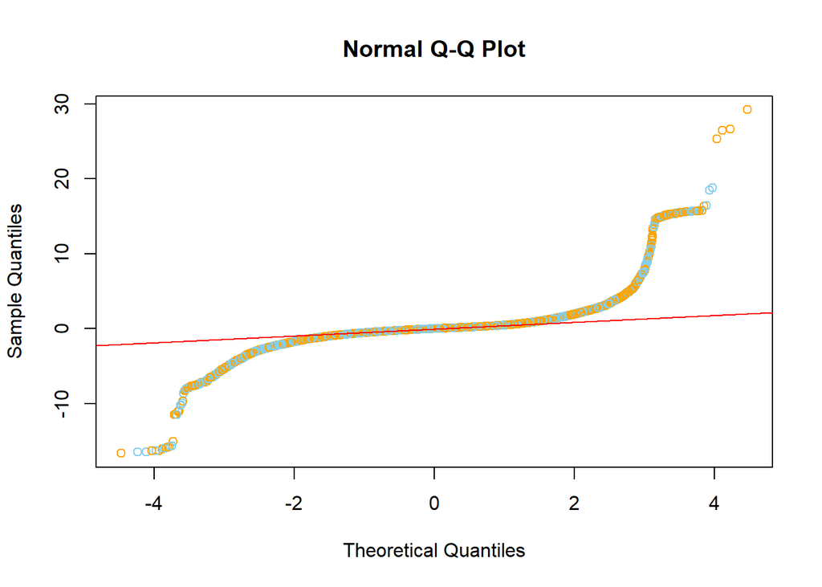

```r
#normalidad
qqnorm(residuos2,col=c("orange","skyblue"))
qqline(residuos2,col="red")
```

Regresión múltiple

```
##
## Call:
## lm(formula = DFCH1$AQI ~ DFCH1$PM2.5 + DFCH1$PM10)
##
## Residuals:
##     Min      1Q  Median      3Q     Max
## -668.68  -29.42  -11.76   17.34  519.49
##
## Coefficients:
##              Estimate Std. Error t value Pr(>|t|)
## (Intercept) 47.596357   0.239267   198.9   <2e-16 ***
## DFCH1$PM2.5  0.698066   0.004636   150.6   <2e-16 ***
## DFCH1$PM10   0.414629   0.002899   143.0   <2e-16 ***
## ---
## Signif. codes:  0 '***' 0.001 '**' 0.01 '*' 0.05 '.' 0.1 ' ' 1
##
## Residual standard error: 52.41 on 129274 degrees of freedom
## Multiple R-squared:  0.7081, Adjusted R-squared:  0.7081
## F-statistic: 1.568e+05 on 2 and 129274 DF,  p-value: < 2.2e-16
```

```
## (Intercept) DFCH1$PM2.5  DFCH1$PM10
##  47.5963574   0.6980665   0.4146288
```

Variable 1 (PM2.5)

$$H_0:\beta_1=0$$
$$H_1:\beta_1≠0$$

Variable 2 (PM10)

$$H_0:\beta_2=0$$
$$H_1:\beta_2≠0$$

Análisis: Respecto a los coeficientes, el intercepto tiene un p value de 2e-16, la variable PM10 tiene un p value de 2e-16 y la variable PM2.5 tiene un p value de 2e-16, los cuales son menores al nivel de significancia (0.05) y por tanto rechazamos la hipótesis nula, lo que muestra que tanto el intercepto como la variable PM10 y la variable PM2.5 sí aportan al modelo propuesto.

Modelo:

Respecto al modelo, se tiene un p value de 2.2e-16, lo cual es menor al nivel de significancia (0.05) y por tanto rechazamos la hipótesis nula, lo que muestra que el modelo sí es significativo.

$$R^2=0.7081$$

0.7081 de la variación del AQI está representado por la variación del valor del PM2.5 y la variación del valor del PM10.

## 5. Conclusiones

Los horarios que no son recomendables son de las 20:00 horas a 04:00 horas puesto que se observa una tendencia en todos los años ya que entre estas horas se produce una gran cantidad de contaminantes, aproximadamente 2000 ug/m3. Todo ello se debe a la gran actividad que realizan las empresas, así como tiendas nocturnas que conllevan a la liberación de gases contaminantes. Asimismo, se determinó que el principal contaminante en India es el CO y que los meses donde se producen más contaminantes son enero, febrero, noviembre y diciembre. Esto se debe a que hay diversas festividades y fenómenos naturales que se producen en India. Por otro lado, dado las pruebas de hipótesis planteadas, se concluye que los límites establecidos por la OMS son ampliamente superados para los contaminantes PM2.5 y PM10. Además, se detectó que la ciudad más contaminada en India es Delhi, debido a la gran cantidad de población que posee a comparación de las demás ciudades. Por último, se encontró una correlación positiva y fuerte entre las variables PM2.5, PM10 y el AQI con un valor de aproximadamente 0.80. En el cual, se pudo identificar distintos modelos para la regresión entre variables que nos ayudarán a predecir nuevos valores.

## 6. Planificación

[interactive chart not shown]